# Dunlop growth rates - habitat

Cassandra Wattenburger

11/10/2020

**Goal of this script:** Investigate the effects of soil habitat on in-situ growth rates

# Import libraries

```r
library(tidyverse)
library(data.table)
library(phyloseq)
library(lmerTest)
```

Import estimated growth rates:

```r
gr.est = readRDS("rdata.files/gr_gr.final.cleaned.rds")
```

# Growth rate habitat distributions

Average across replicates: makes for cleaner presentation.

```r
gr.estavg = gr.est %>%
  group_by(Soil, Amendment, ASV, Domain, Phylum, Class, Order, Family, Genus) %>%
  summarize(avgk = mean(k), avgStart = mean(Start), avgEnd = mean(End), avgLength = mean(Length))
```

Kernel density graphs

See: https://www.statsmodels.org/dev/examples/notebooks/generated/kernel_density.html

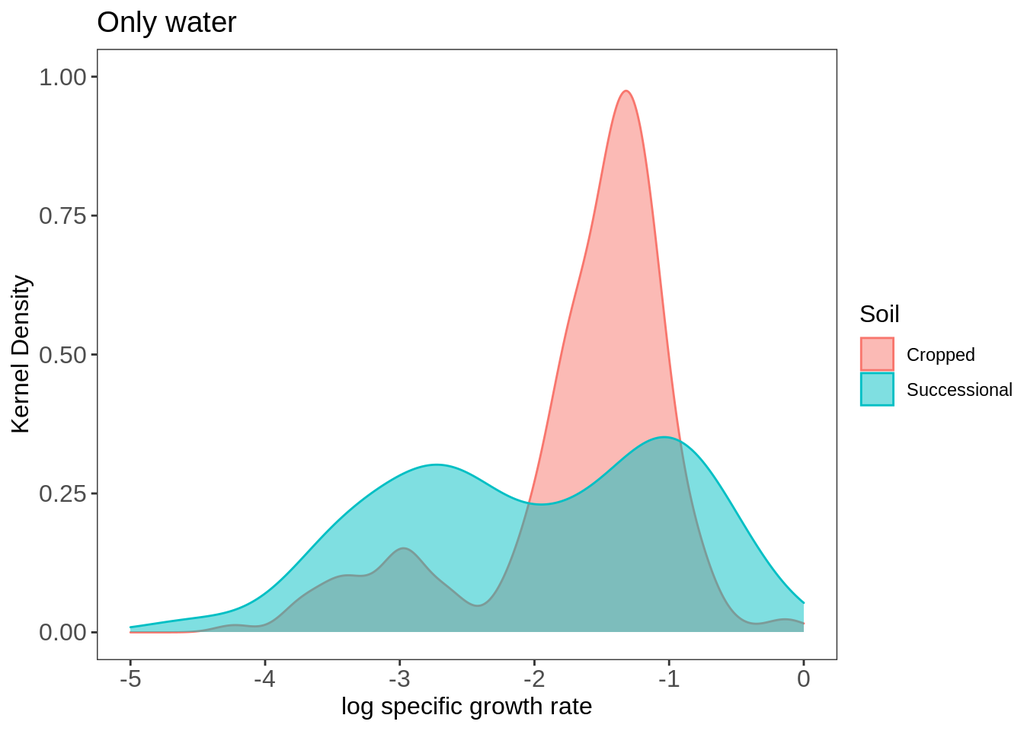

```r
gr.estavg %>%
  filter(Amendment=="N") %>%
  ggplot(aes(x=log(avgk), color=Soil, fill=Soil)) +
  geom_density(alpha=0.5) +
  labs(title="Only water", x="log specific growth rate", y="Kernel Density") +
  theme_test() +
  theme(#legend.position="none",
        title=element_text(size=12),
        axis.text=element_text(size=12),
        axis.title=element_text(size=12)) +
  scale_color_manual(labels = c("Cropped", "Successional"), values=c("#F8766D","#00BFC4")) +
  scale_fill_manual(labels = c("Cropped", "Successional"), values=c("#F8766D","#00BFC4")) +
  scale_y_continuous(limits=c(0,1)) +
  scale_x_continuous(limits=c(-5,0))
```

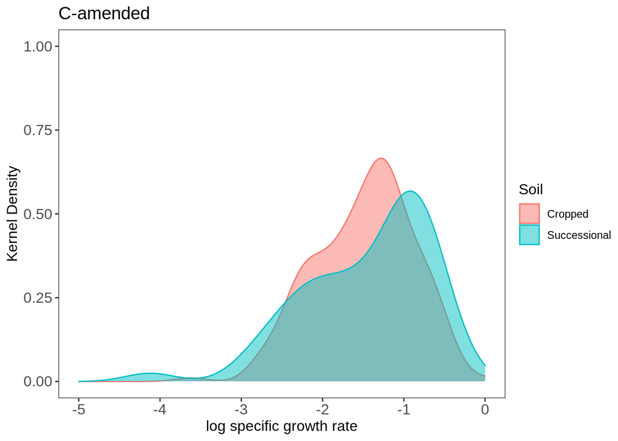

```r
gr.estavg %>%
  filter(Amendment=="Y") %>%
  ggplot(aes(x=log(avgk), color=Soil, fill=Soil)) +
  geom_density(alpha=0.5) +
  labs(title="C-amended", x="log specific growth rate", y="Kernel Density") +
  theme_test() +
  theme(#legend.position="none",
        title=element_text(size=12),
        axis.text=element_text(size=12),
        axis.title=element_text(size=12)) +
  scale_color_manual(labels = c("Cropped", "Successional"), values=c("#F8766D","#00BFC4")) +
  scale_fill_manual(labels = c("Cropped", "Successional"), values=c("#F8766D","#00BFC4")) +
  scale_y_continuous(limits=c(0,1)) +
  scale_x_continuous(limits=c(-5,0))
```

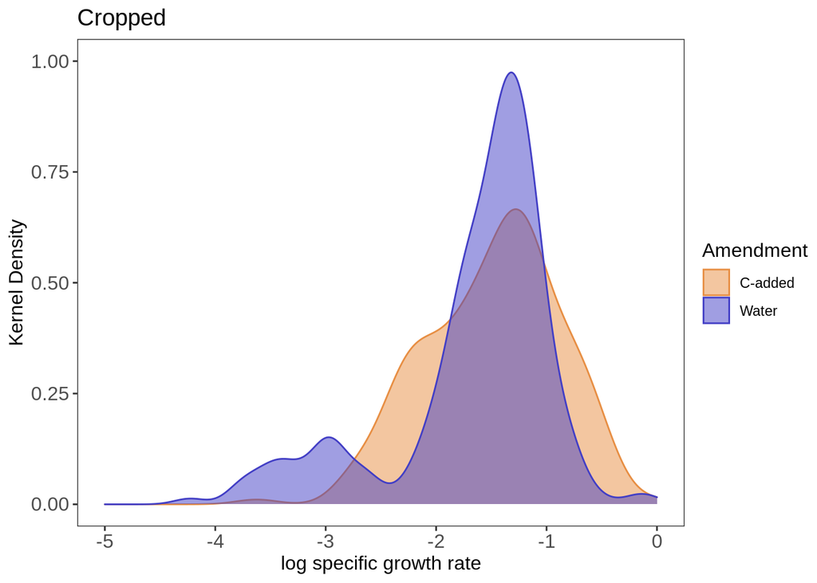

```r
gr.estavg %>%
  filter(Soil=="C3") %>%
  ggplot(aes(x=log(avgk), color=Amendment, fill=Amendment)) +
  geom_density(alpha=0.5) +
  labs(title="Cropped", x="log specific growth rate", y="Kernel Density") +
  theme_test() +
  theme(#legend.position="none",
        title=element_text(size=12),
        axis.text=element_text(size=12),
        axis.title=element_text(size=12)) +
  scale_color_manual(labels = c("C-added", "Water"), values=c("#E78E43", "#423EC5")) +
  scale_fill_manual(labels = c("C-added", "Water"), values=c("#E78E43", "#423EC5")) +
  scale_y_continuous(limits=c(0,1)) +
  scale_x_continuous(limits=c(-5,0))
```

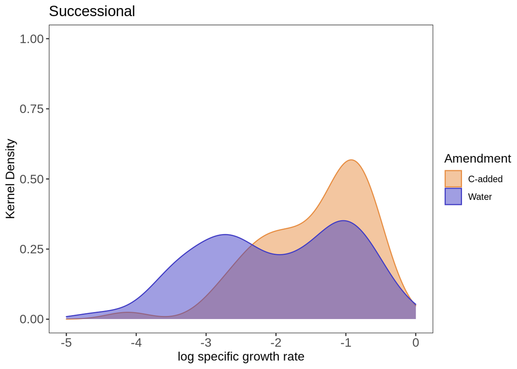

```r
gr.estavg %>%
  filter(Soil=="S17") %>%
  ggplot(aes(x=log(avgk), color=Amendment, fill=Amendment)) +
  geom_density(alpha=0.5) +
  labs(title="Successional", x="log specific growth rate", y="Kernel Density") +
  theme_test() +
  theme(#legend.position="none",
        title=element_text(size=12),
        axis.text=element_text(size=12),
        axis.title=element_text(size=12)) +
  scale_color_manual(labels = c("C-added", "Water"), values=c("#E78E43", "#423EC5")) +
  scale_fill_manual(labels = c("C-added", "Water"), values=c("#E78E43", "#423EC5")) +
  scale_y_continuous(limits=c(0,1)) +
  scale_x_continuous(limits=c(-5,0))
```

# Growth rate distribution binning

Hypothesis: growth rate distributions will differ by soil and by amendment.

In order to conduct tests on the distirbution of the data, I need to bin it discretely. The bins will need to be equal width and have the same start and end points across treatments so that they are comparable, and the number of bins must be chosen to simplify the data without losing too much of the “shape” of the distribution (see smoothed histograms above for reference).

Ranging from 5 to 10 bins.

Overall:

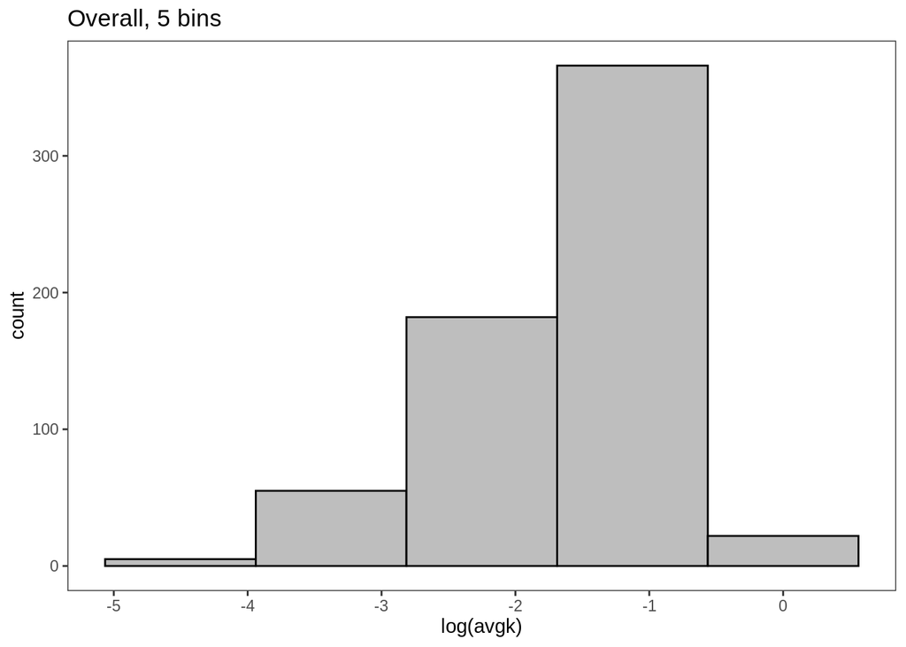

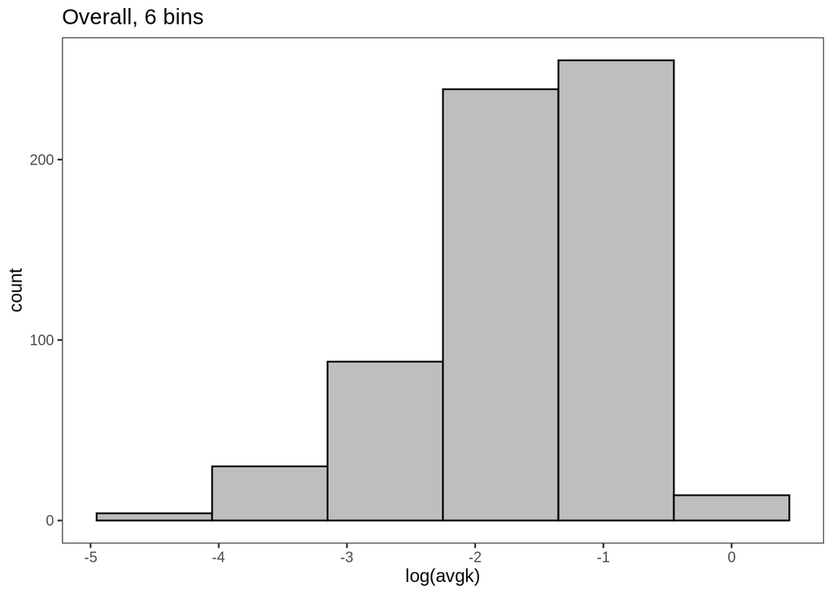

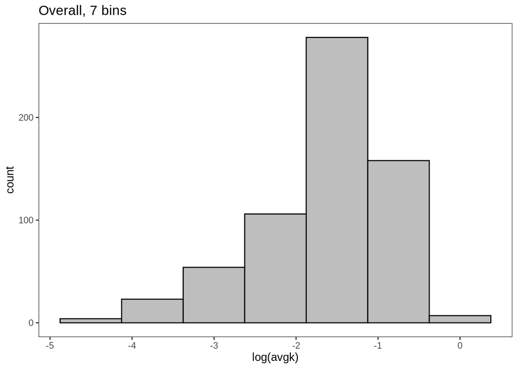

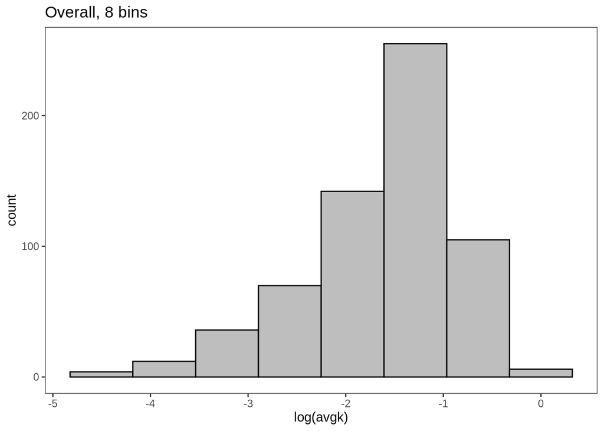

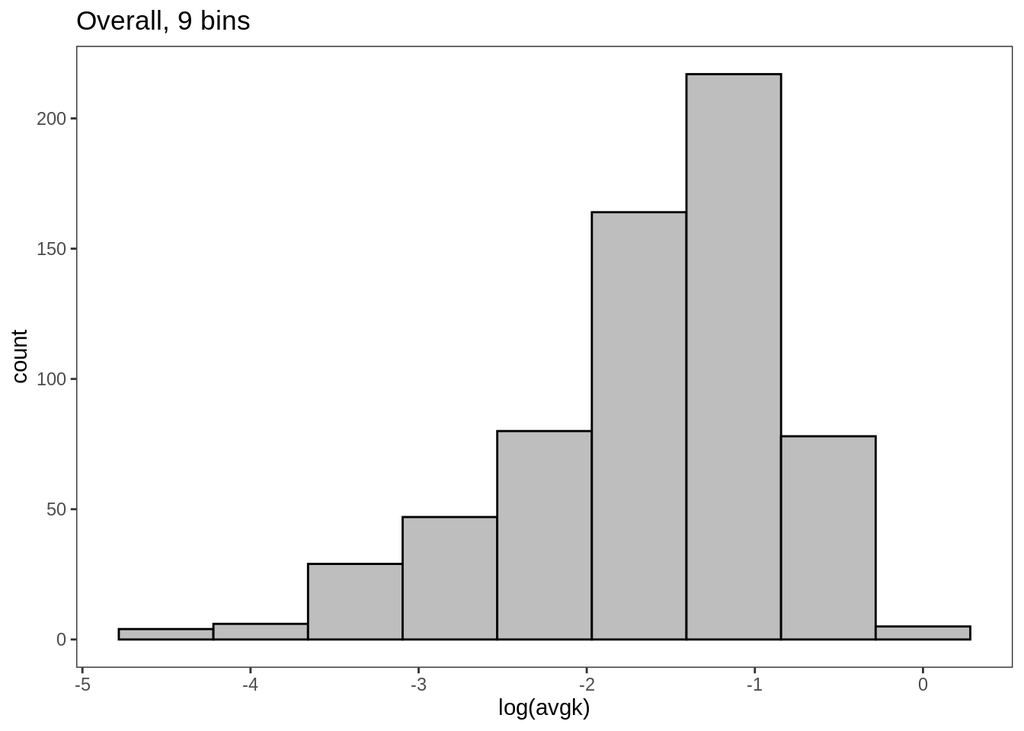

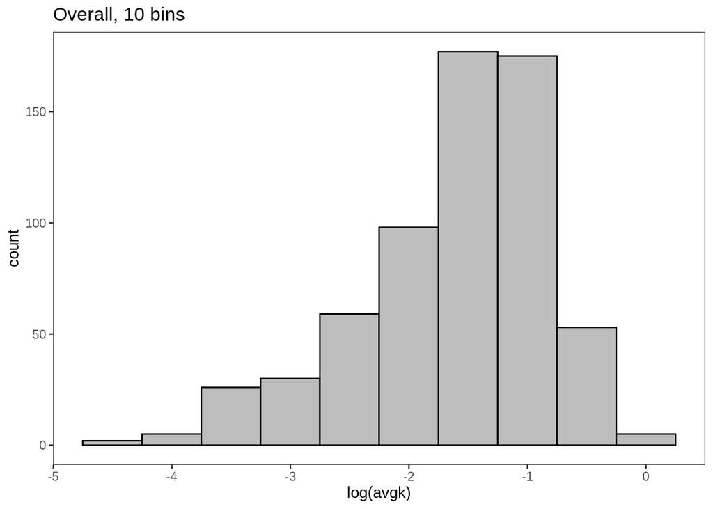

```r
for (i in 5:10) {
  print(gr.estavg %>%
    ggplot(aes(x=log(avgk))) +
    geom_histogram(bins=i, color="black", fill="gray") +
    theme_test() +
    labs(title=paste("Overall,", i, "bins", sep=" ")))
}
```

Treatments:

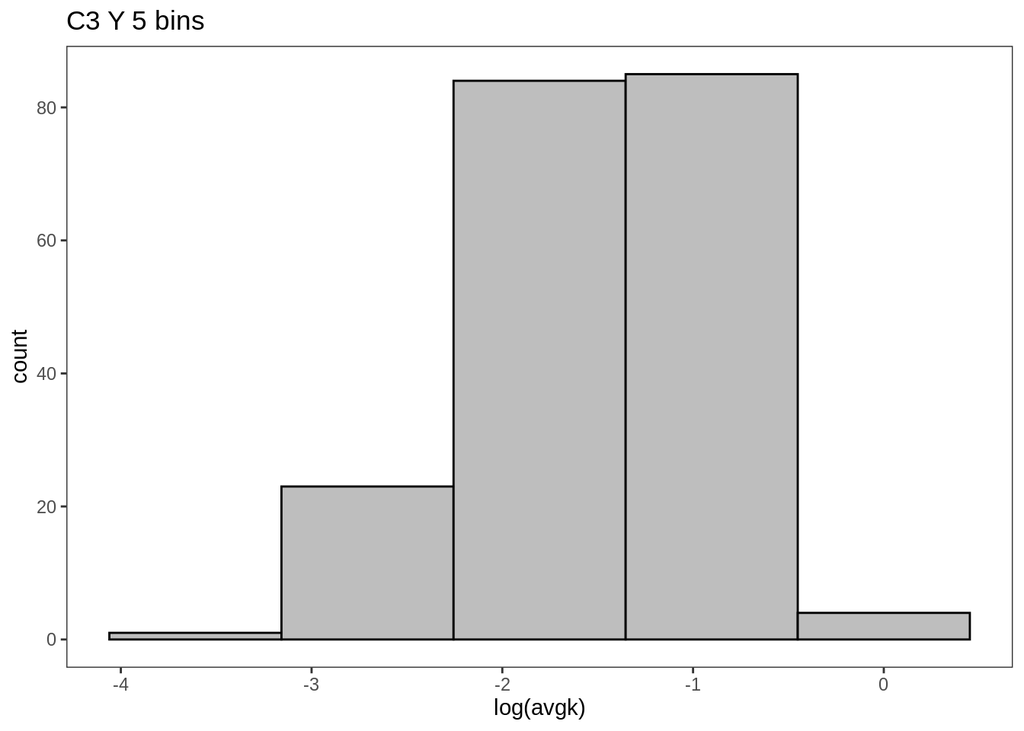

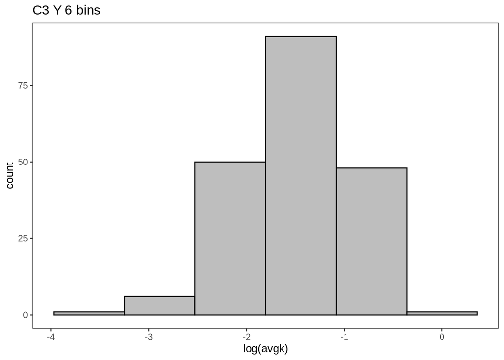

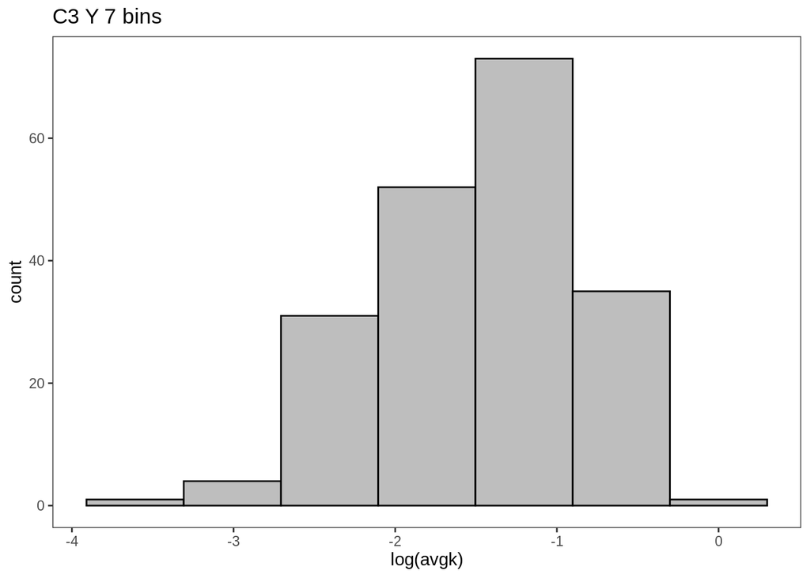

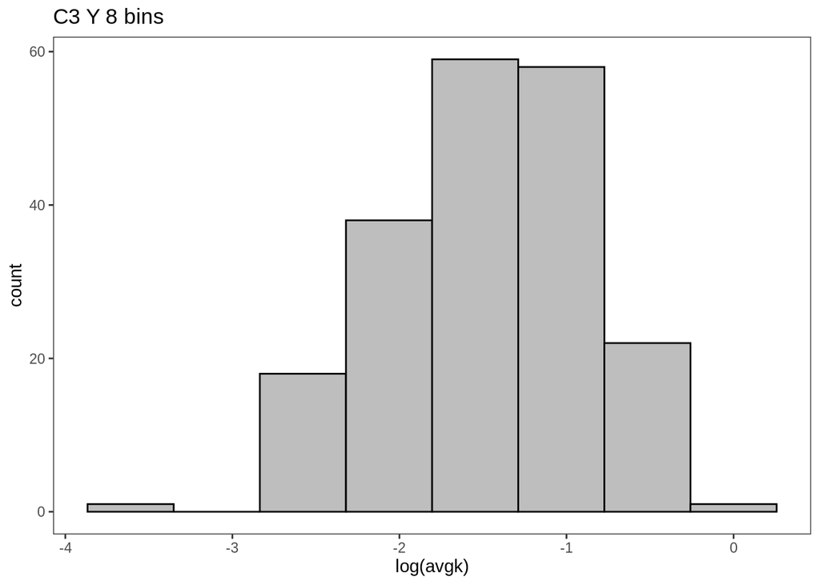

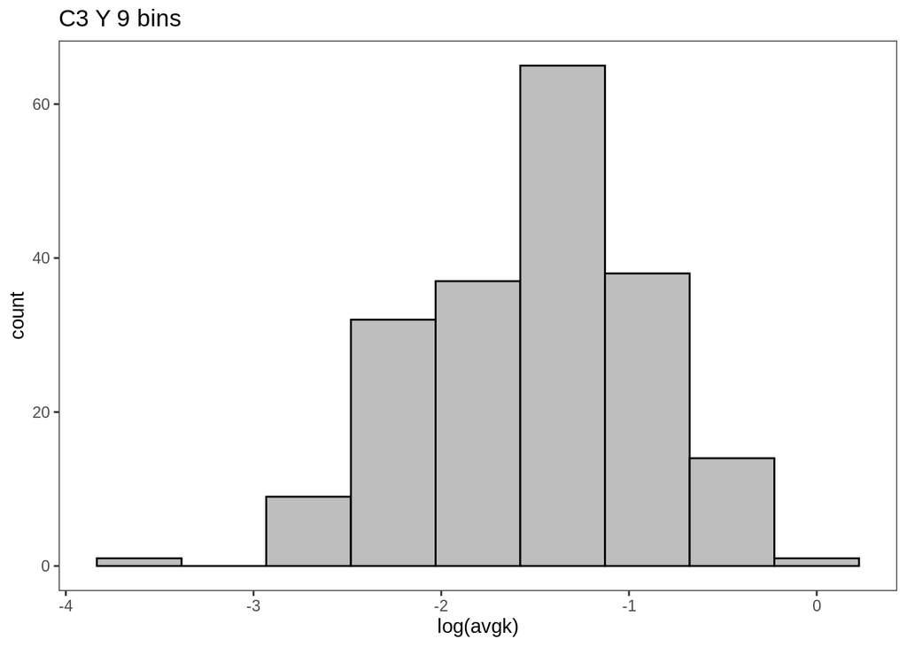

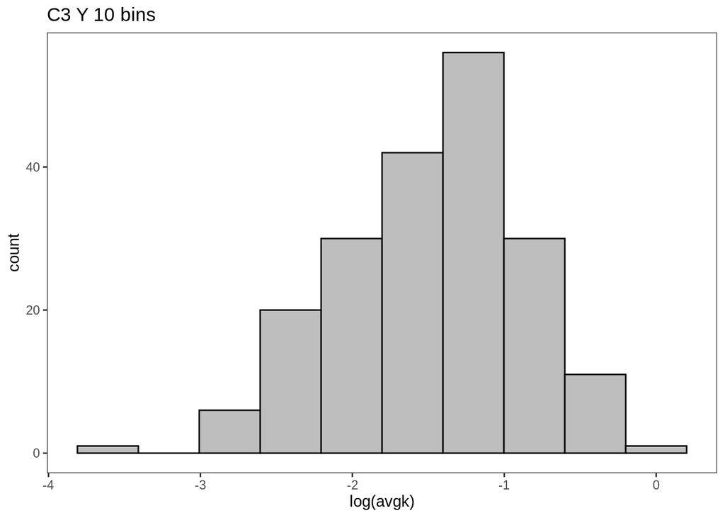

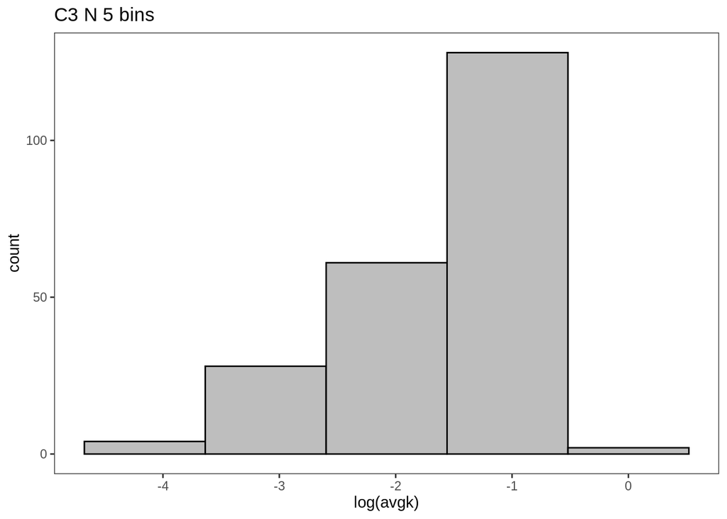

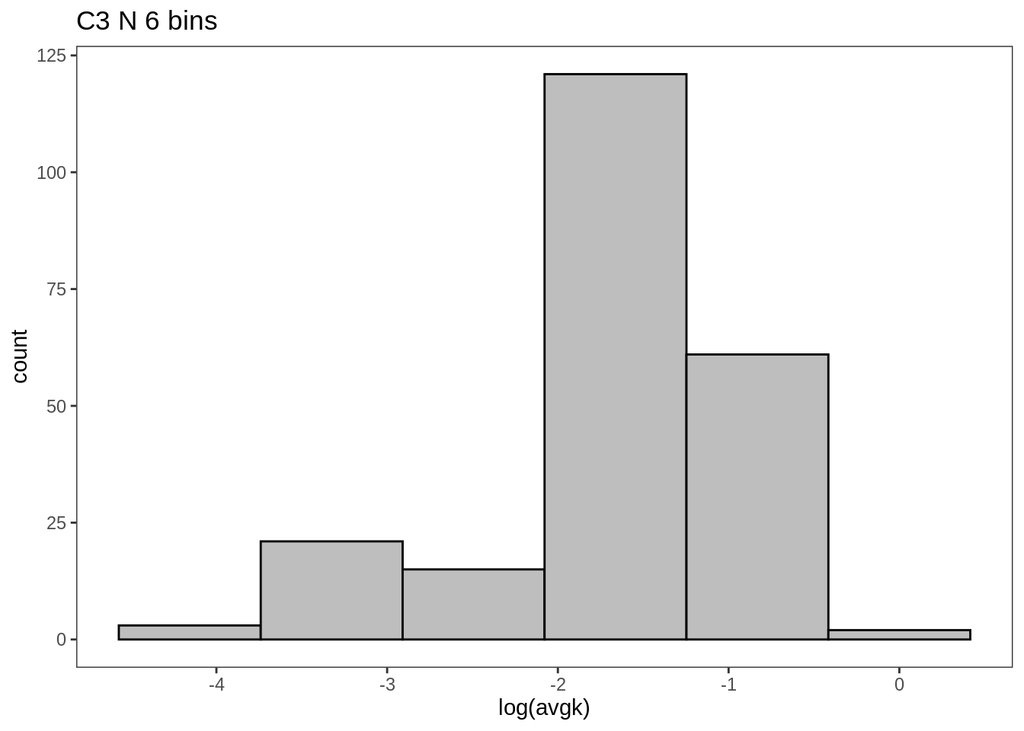

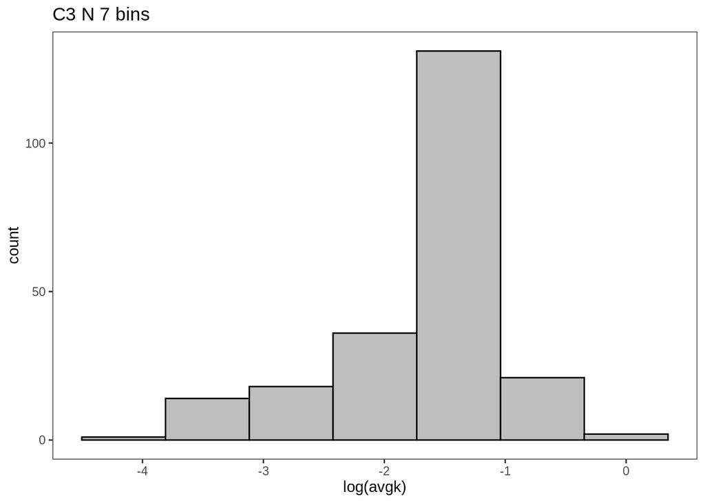

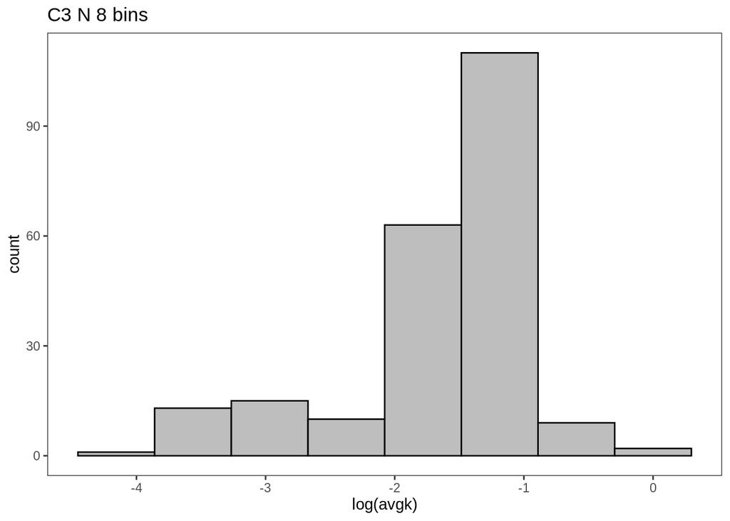

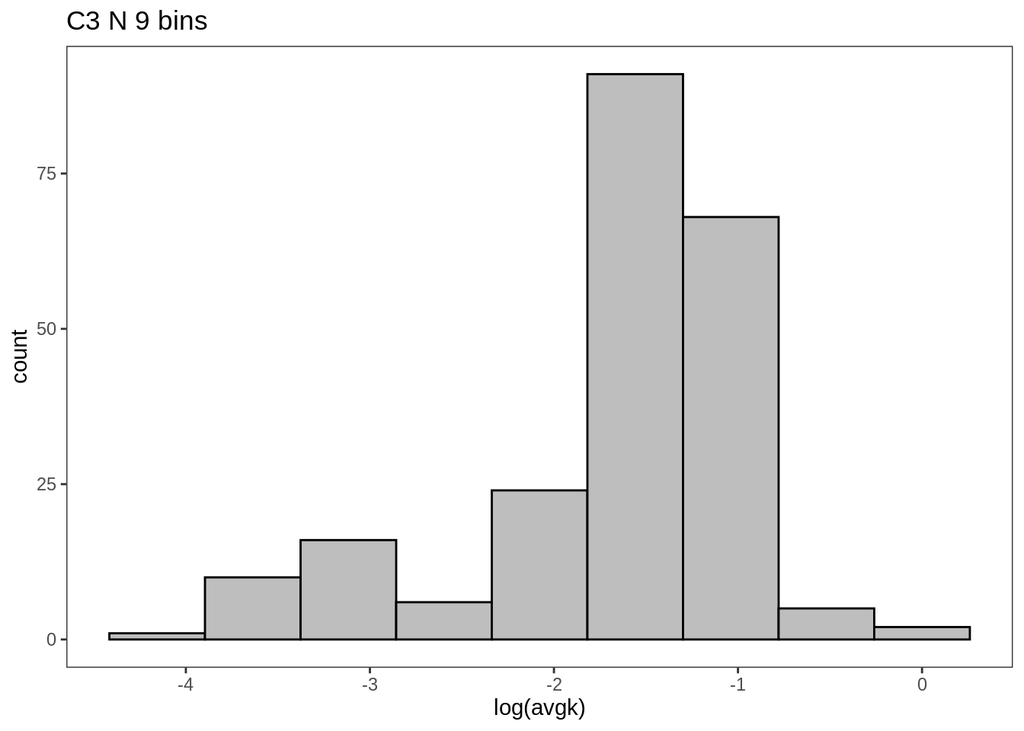

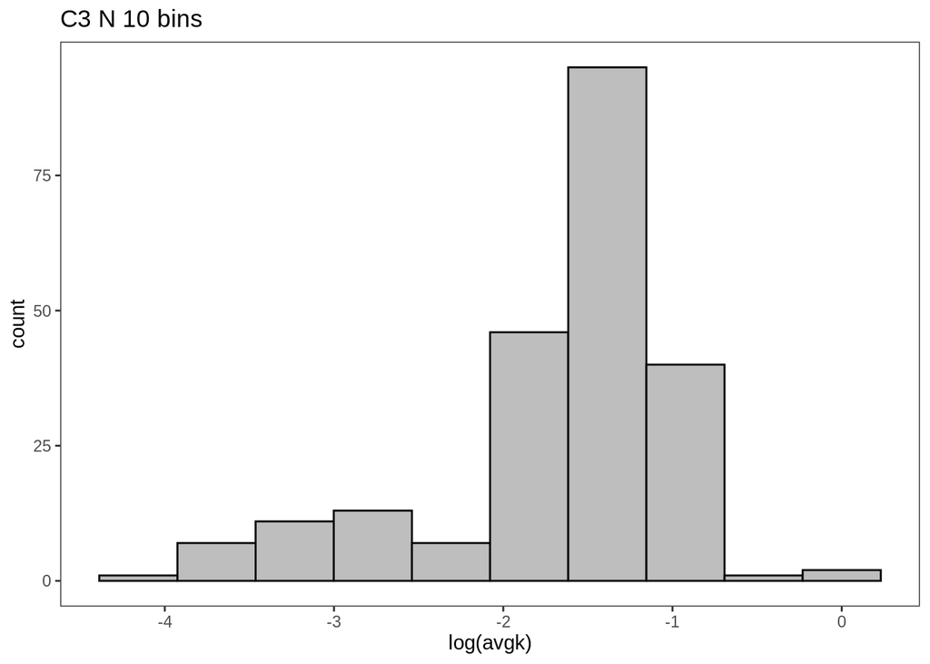

[12 more figures not shown]

```r
for (s in c("C3", "S17")) {
  for (a in c("Y", "N")) {
    for (i in 5:10) {
      print(gr.estavg %>%
        filter(Soil==s, Amendment==a) %>%
        ggplot(aes(x=log(avgk))) +
        geom_histogram(bins=i, color="black", fill="gray") +
        theme_test() +
        labs(title=paste(s, a, i, "bins")))
    }
  }
}
```

It looks like 5 bins is too few, 6 or 7 seem to more adequately capture the distributions. I’ll choose 7 bins.

There need to be the same number and width of bins in each dataset.

Caculate min, max, and range of specific growth rate values in whole dataset:

```r
print(paste("Min:", min(log(gr.estavg$avgk))))
```

```
## [1] "Min: -4.51760171995445"
```

```r
print(paste("Max:", max(log(gr.estavg$avgk))))
```

```
## [1] "Max: -0.0155326196739766"
```

```r
print(paste("Range:", max(log(gr.estavg$avgk))-min(log(gr.estavg$avgk))))
```

```
## [1] "Range: 4.50206910028048"
```

Calculate bin width based on range:

```r
width = (max(log(gr.estavg$avgk))-min(log(gr.estavg$avgk)))/7
print(paste("Bin width:", width))
```

```
## [1] "Bin width: 0.643152728611497"
```

```r
kmin=min(log(gr.estavg$avgk))
print(paste("Bin 1 boundaries: less than", kmin+width))
```

```
## [1] "Bin 1 boundaries: less than -3.87444899134296"
```

```r
print(paste("Bin 2 boundaries:", kmin+width, "to",  kmin+width*2))
```

```
## [1] "Bin 2 boundaries: -3.87444899134296 to -3.23129626273146"
```

```r
print(paste("Bin 3 boundaries:", kmin+width*2, "to",  kmin+width*3))
```

```
## [1] "Bin 3 boundaries: -3.23129626273146 to -2.58814353411996"
```

```r
print(paste("Bin 4 boundaries:", kmin+width*3, "to",  kmin+width*4))
```

```
## [1] "Bin 4 boundaries: -2.58814353411996 to -1.94499080550847"
```

```r
print(paste("Bin 5 boundaries:", kmin+width*4, "to",  kmin+width*5))
```

```
## [1] "Bin 5 boundaries: -1.94499080550847 to -1.30183807689697"
```

```r
print(paste("Bin 6 boundaries:", kmin+width*5, "to",  kmin+width*6))
```

```
## [1] "Bin 6 boundaries: -1.30183807689697 to -0.658685348285473"
```

```r
print(paste("Bin 7 boundaries:", kmin+width*6, "and greater"))
```

```
## [1] "Bin 7 boundaries: -0.658685348285473 and greater"
```

```r
# Bin data based on boundaries chosen and log k
gr.est.bins = gr.est %>% mutate(bin = ifelse(log(k) < kmin+width, 1, ifelse(log(k) < kmin+width*2, 2, ifelse(log(k) < kmin+width*3, 3, ifelse(log(k) < kmin+width*4, 4, ifelse(log(k) < kmin+width*5, 5, ifelse(log(k) < kmin+width*6, 6, 7)))))))

# Calculate bin information (proportion, frequency)
gr.bins = data.frame()
for (s in as.character(unique(gr.est.bins$Soil))) {
  for (a in as.character(unique(gr.est.bins$Amendment))) {
    for (r in as.character(unique(gr.est.bins$Replicate))) {
      total = nrow(gr.est.bins[gr.est.bins$Soil==s & gr.est.bins$Amendment==a & gr.est.bins$Replicate==r,])
      for (b in as.character(unique(gr.est.bins$bin))) {
        bin = gr.est.bins[gr.est.bins$Soil==s & gr.est.bins$Amendment==a & gr.est.bins$Replicate==r & gr.est.bins$bin==b,]
        binfreq = nrow(bin)
        binratio = binfreq/total
        thisrow = data.frame(s, a, r, b, binfreq, binratio)
        gr.bins = rbind(gr.bins, thisrow)
      }
    }
  }
}
colnames(gr.bins) = c("Soil","Amendment","Replicate","bin","frequency","proportion")
gr.bins$bin = factor(gr.bins$bin, levels=c(1,2,3,4,5,6,7))
```

Plot bins:

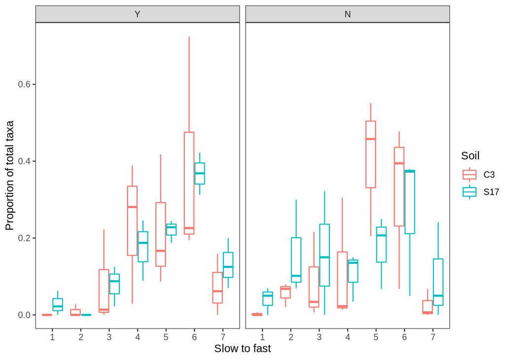

```r
ggplot(gr.bins) +
  geom_boxplot(aes(x=bin, y=proportion, color=Soil)) +
  facet_wrap(~Amendment) +
  theme_test() +
  labs(x="Slow to fast", y="Proportion of total taxa")
```

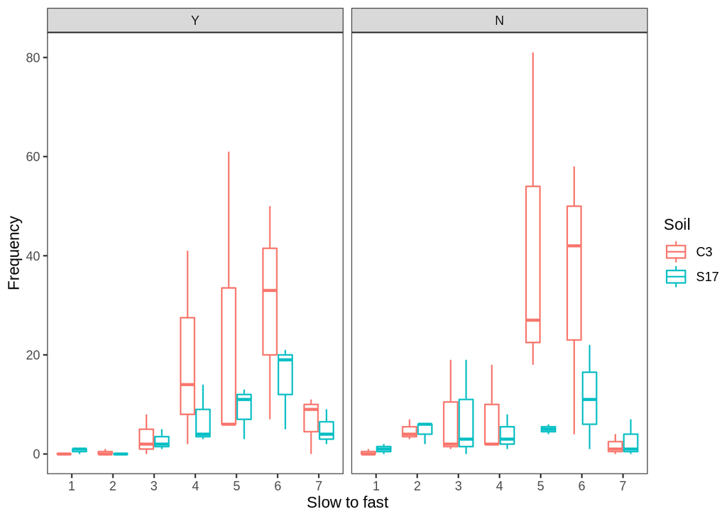

```r
ggplot(gr.bins) +
  geom_boxplot(aes(x=bin, y=frequency, color=Soil)) +
  facet_wrap(~Amendment) +
  theme_test() +
  labs(x="Slow to fast", y="Frequency")
```

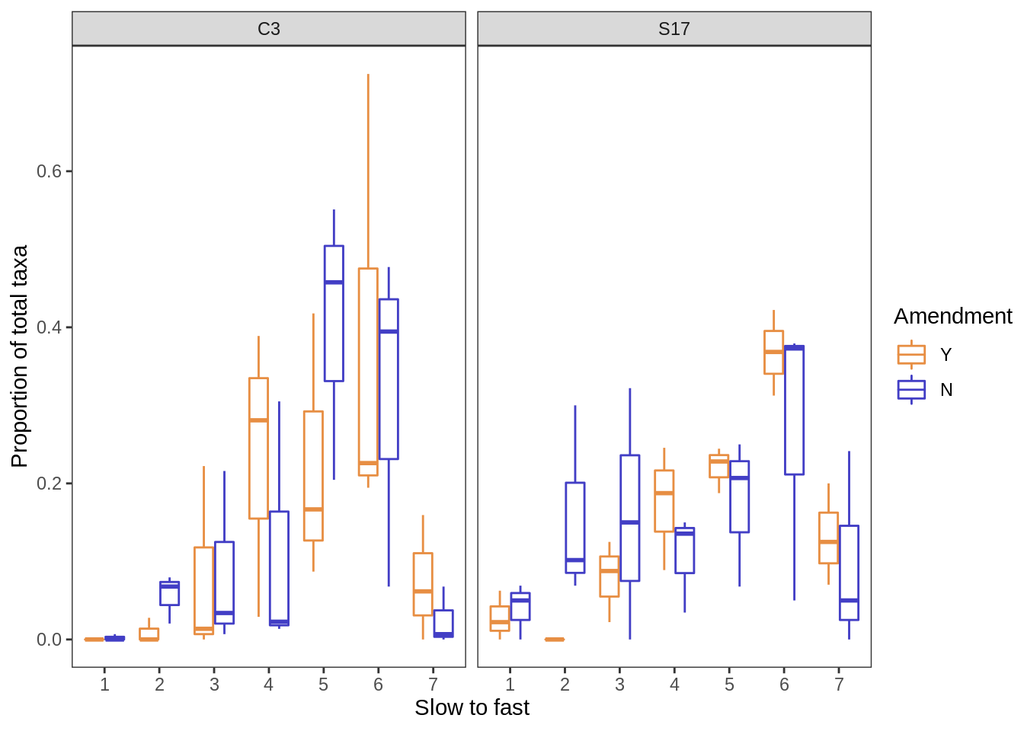

```r
ggplot(gr.bins) +
  geom_boxplot(aes(x=bin, y=proportion, color=Amendment)) +
  facet_wrap(~Soil) +
  scale_color_manual(values=c("#E78E43", "#423EC5")) +
  theme_test() +
  labs(x="Slow to fast", y="Proportion of total taxa")
```

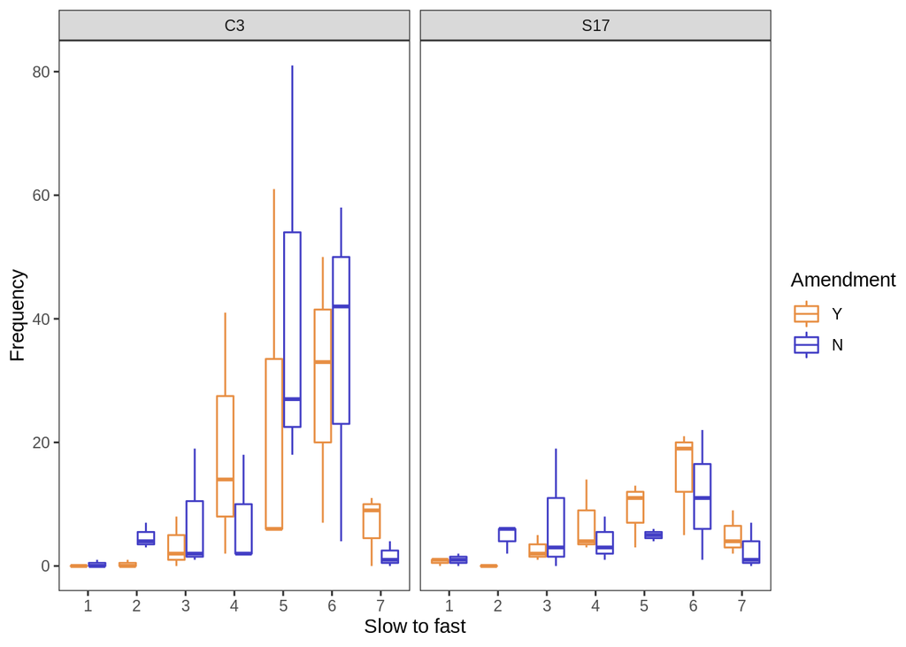

```r
ggplot(gr.bins) +
  geom_boxplot(aes(x=bin, y=frequency, color=Amendment)) +
  facet_wrap(~Soil) +
  scale_color_manual(values=c("#E78E43", "#423EC5")) +
  theme_test() +
  labs(x="Slow to fast", y="Frequency")
```

**Statistics**

First, I want to know if the distribution of growth rates differs by habitat or amendment. I’ll use a contingency table and Fisher’s exact test.

See: http://www.biostathandbook.com/fishers.html

```r
# Average replicates and round (Frischer's needs integers, not continuous numbers)
gr.bins.avg = gr.bins %>% group_by(Soil, Amendment, bin) %>% summarize(avgfreq = mean(frequency)) %>% mutate(avgfreq.rnd = round(avgfreq))
# Make contingency tables
conting.y = dcast(gr.bins.avg[gr.bins.avg$Amendment=="Y",], Soil~bin, value.var="avgfreq.rnd")
conting.y = conting.y[,-1] %>% as.matrix()

conting.n = dcast(gr.bins.avg[gr.bins.avg$Amendment=="N",], Soil~bin, value.var="avgfreq.rnd")
conting.n = conting.n[,-1] %>% as.matrix()

conting.C3 = dcast(gr.bins.avg[gr.bins.avg$Soil=="C3",], Amendment~bin, value.var="avgfreq.rnd")
conting.C3 = conting.C3[,-1] %>% as.matrix()

conting.S17 = dcast(gr.bins.avg[gr.bins.avg$Soil=="S17",], Amendment~bin, value.var="avgfreq.rnd")
conting.S17 = conting.S17[,-1] %>% as.matrix()

# Run Fisher's exact tests
set.seed(1)
fish.testy = fisher.test(conting.y, simulate.p.value = TRUE)
fish.testn = fisher.test(conting.n, simulate.p.value = TRUE)
fish.testC3 = fisher.test(conting.C3, simulate.p.value = TRUE)
fish.testS17 = fisher.test(conting.S17, simulate.p.value = TRUE)

# Multiple test correction
fish.pvals = c(fish.testn$p.value, fish.testy$p.value, fish.testC3$p.value, fish.testS17$p.value)
fish.padj = p.adjust(fish.pvals, method="holm", n=length(fish.pvals))
print(paste("Unamended cropped vs Succ., adj. p-value:", fish.padj[1]))
```

```
## [1] "Unamended cropped vs Succ., adj. p-value: 0.00399800099950025"
```

```r
print(paste("Amended cropped vs Succ., adj. p-value:", fish.padj[2]))
```

```
## [1] "Amended cropped vs Succ., adj. p-value: 0.547226386806597"
```

```r
print(paste("Cropped amended vs unamended, adj. p-value:", fish.padj[3]))
```

```
## [1] "Cropped amended vs unamended, adj. p-value: 0.00899550224887556"
```

```r
print(paste("Succ. amended vs unamended, adj. p-value:", fish.padj[4]))
```

```
## [1] "Succ. amended vs unamended, adj. p-value: 0.254872563718141"
```

# Growth rate shift up/down

Among ASVs that were estimated in both cropped and successional soil treatments, do they reliably shift up or down in growth rate?

Hypotheses:

1. ASVs found in water and C-amended treatments will grow faster in the C-amended treatment in both soils because of higher resource availability.
2. ASVs found in both cropped and successional soils overall will grow faster in the cropped soil because of greater disturbances in the cropped soil.

```r
# Isolate treatment data
gr.C3.avgk = gr.est %>%
  filter(Soil=="C3") %>%
  group_by(Soil, ASV) %>%
  summarize(C3.avgk=mean(k))
gr.S17.avgk = gr.est %>%
  filter(Soil=="S17") %>%
  group_by(Soil, ASV) %>%
  summarize(S17.avgk=mean(k))
gr.C3y.avgk = gr.est %>%
  filter(Soil=="C3", Amendment=="Y") %>%
  group_by(Soil, Amendment, ASV) %>%
  summarize(C3y.avgk=mean(k))
gr.C3n.avgk = gr.est %>%
  filter(Soil=="C3", Amendment=="N") %>%
  group_by(Soil, Amendment, ASV) %>%
  summarize(C3n.avgk=mean(k))
gr.S17y.avgk = gr.est %>%
  filter(Soil=="S17", Amendment=="Y") %>%
  group_by(Soil, Amendment, ASV) %>%
  summarize(S17y.avgk=mean(k))
gr.S17n.avgk = gr.est %>%
  filter(Soil=="S17", Amendment=="N") %>%
  group_by(Soil, Amendment, ASV) %>%
  summarize(S17n.avgk=mean(k))
```

Visualize:

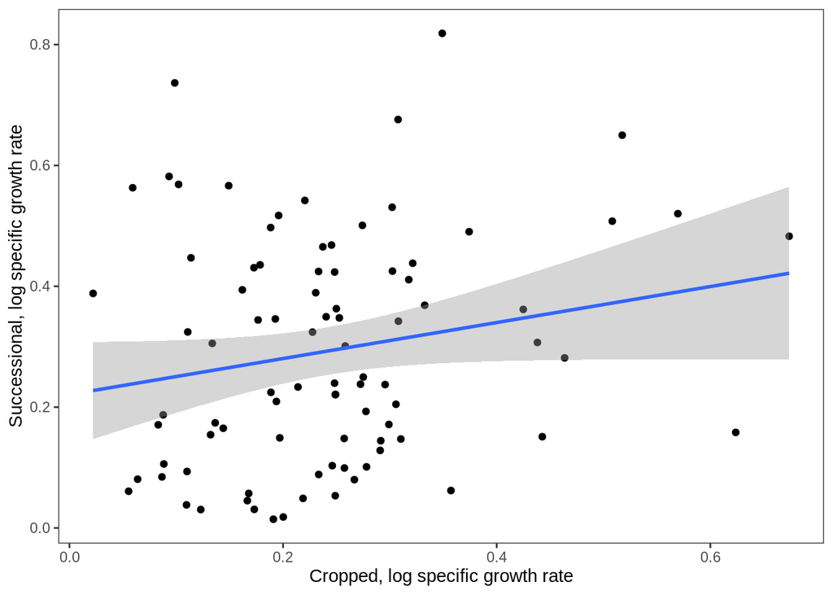

```r
# Overall cropped vs succesional
inner_join(gr.C3.avgk, gr.S17.avgk, by="ASV") %>%
  ggplot(aes(x=C3.avgk, y=S17.avgk)) +
  geom_point() +
  geom_smooth(method="lm") +
  labs(x="Cropped, log specific growth rate", y="Successional, log specific growth rate") +
  theme_test()
```

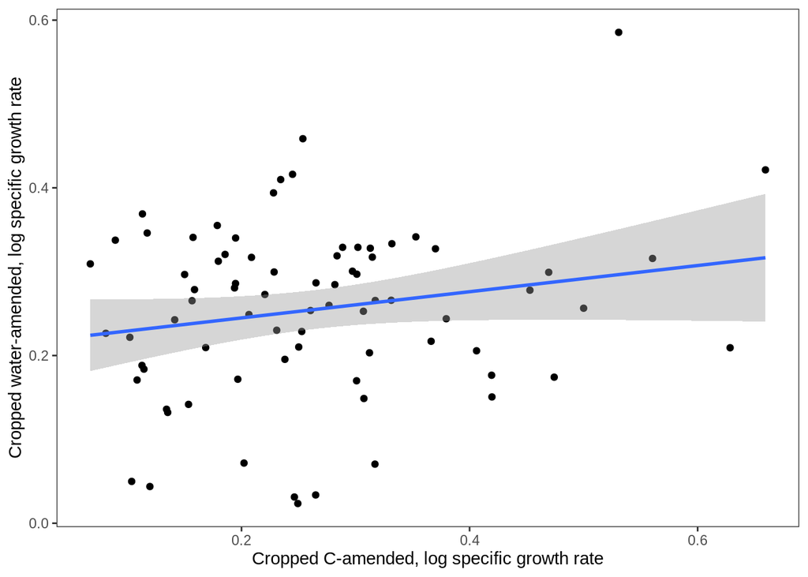

```r
# Cropped C-amended vs water
inner_join(gr.C3y.avgk, gr.C3n.avgk, by="ASV") %>%
  ggplot(aes(x=C3y.avgk, y=C3n.avgk)) +
  geom_point() +
  geom_smooth(method="lm") +
  labs(x="Cropped C-amended, log specific growth rate", y="Cropped water-amended, log specific growth rate") +
  theme_test()
```

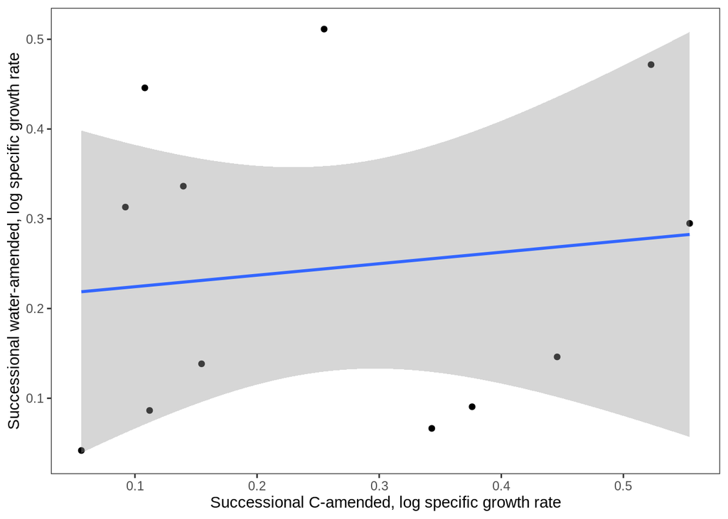

```r
# Succesional C-amended vs water
inner_join(gr.S17y.avgk, gr.S17n.avgk, by="ASV") %>%
  ggplot(aes(x=S17y.avgk, y=S17n.avgk)) +
  geom_point() +
  geom_smooth(method="lm") +
  labs(x="Successional C-amended, log specific growth rate", y="Successional water-amended, log specific growth rate") +
  theme_test()
```

Doesn’t look promising.

**Statistcs**

Try simple linear regression first:

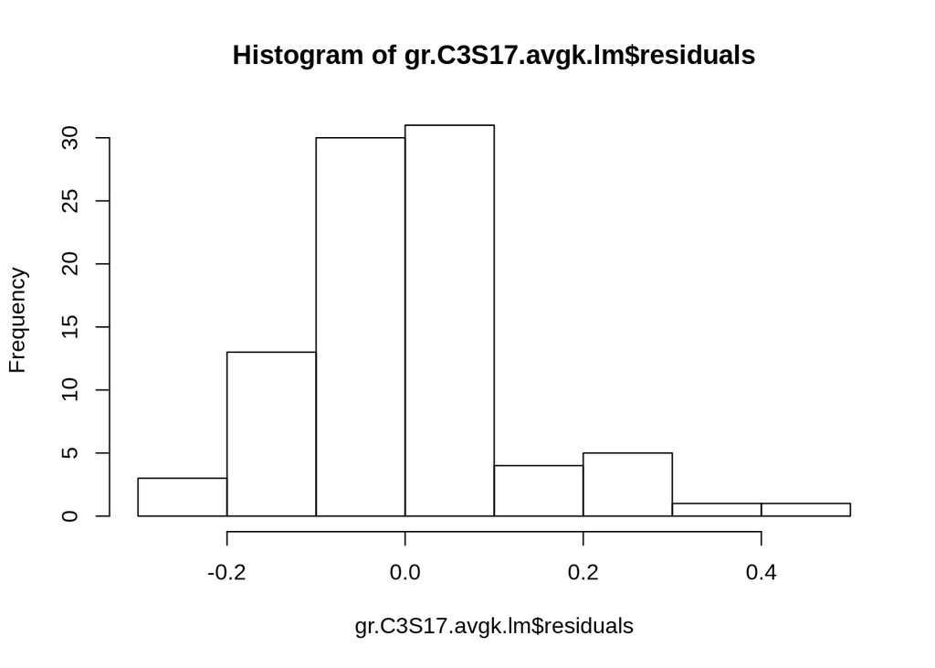

```r
# Test overall cropped vs successional using linear regression
gr.C3S17.avgk = inner_join(gr.C3.avgk, gr.S17.avgk, by="ASV")
gr.C3S17.avgk.lm = lm(C3.avgk ~ S17.avgk, data=gr.C3S17.avgk)

# Evaluate assumptions of linear regression
hist(gr.C3S17.avgk.lm$residuals) # evaluate assumption of normality
```

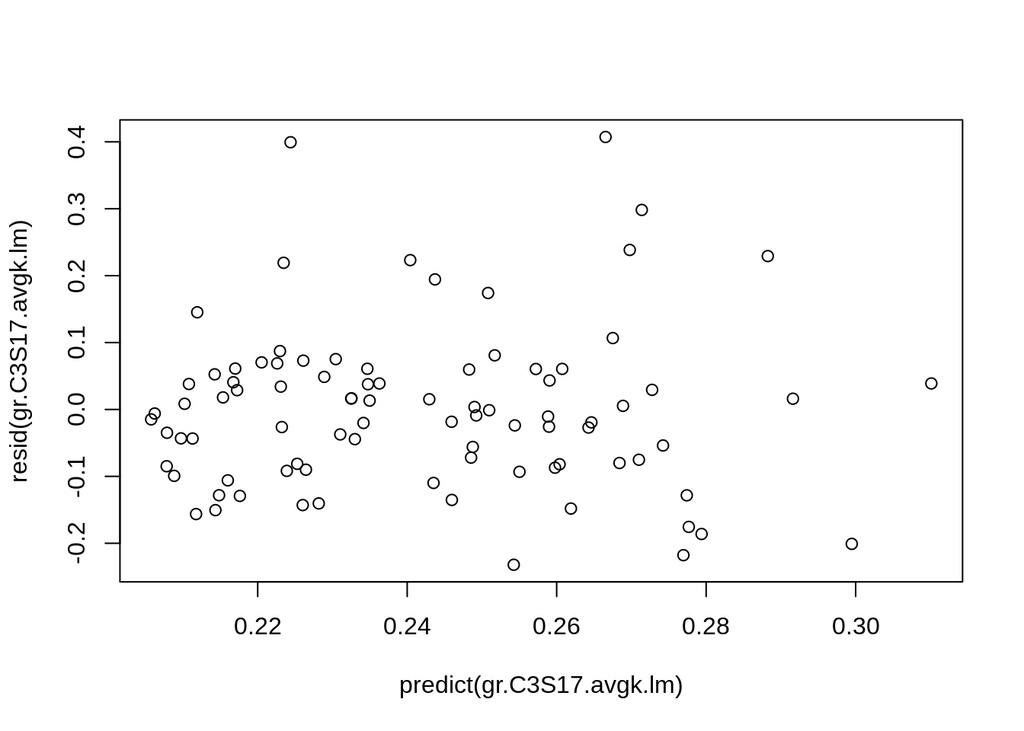

```r
plot(predict(gr.C3S17.avgk.lm), resid(gr.C3S17.avgk.lm)) # evaluate assumption of homoskedasticity
```

```r
# P value
summary(gr.C3S17.avgk.lm)$coefficients[2,4]
```

```
## [1] 0.06631589
```

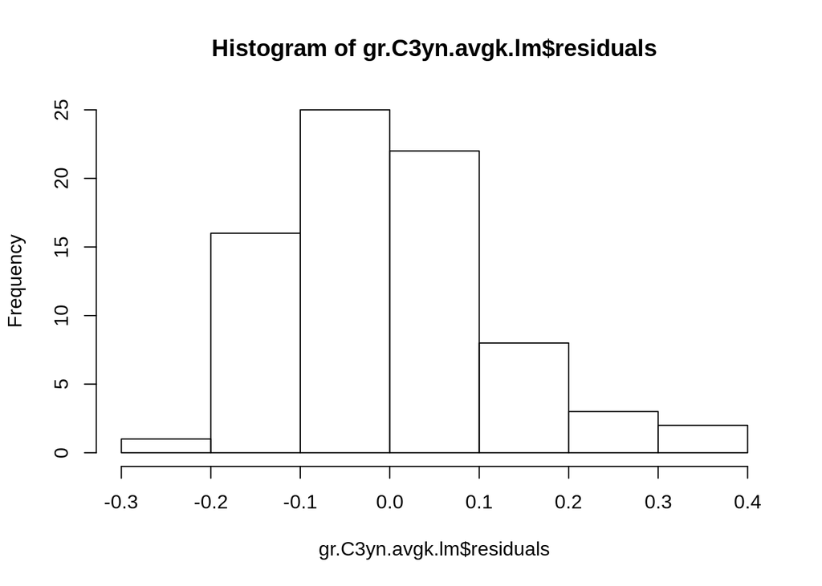

```r
# Cropped C-amended vs water
gr.C3yn.avgk = inner_join(gr.C3y.avgk, gr.C3n.avgk, by="ASV")
gr.C3yn.avgk.lm = lm(C3y.avgk ~ C3n.avgk, data=gr.C3yn.avgk)

# Evaluate assumptions of linear regression
hist(gr.C3yn.avgk.lm$residuals) # evaluate assumption of normality
```